# Wine Quality

2022-03-22

```r
library(ggplot2)
library(ggExtra)
library(gridExtra)
library(ezids)
library(lattice)
library(corrplot)
```

# 1 Chapter 1: Introduction

Wine is an alcoholic beverage that has been produced for over thousands of years and was originally founded in Georgia from 6000BC. The religious root the drink has, caused many to consume in the remembrance of God and this widened the trade across Europe. People consume wine also for its wonderful sweet taste and nutritious properties that are beneficial to health. While there are many types of wines, two of the most famous variants would be the Red and White versions produced mostly in the Europe. Wines that were once expensive to buy, are increasingly enjoyed by consumers around the world and the market is expected to grow annually by 7.22% (CAGR 2022-2025)[1]. Wine industries are researching different methods involved in the process of creating and selling wines at the same time retaining its quality to support its growth. Wines are sold at different price ranges depending on its quality, while the least expensive could be as low as $4, the pinnacle of wines could cost beyond $200 per bottle. Given a bottle of wine could be sold for over $200, we decided to conduct analyses to better understand what gives rise to the quality and their associated benefits by assessing publicly available dataset downloaded from UCI Machine Learning Repository.

```r
wine <- read.csv(file='winequality-white.csv',
                 header=T,
                 sep=";",
                 fill=T,
                 strip.white=T,
                 blank.lines.skip=T,
                 colClasses = c('quality'='factor'))
cnames <- colnames(wine)
cnames_ind <- head(cnames, length(cnames)-1)
wine_ind <- wine[, cnames_ind]
```

# 2 Chapter 2: Description of the data

## 2.1 Source Data

The dataset contains 4898 instances with 11 explanatory and 1 dependent variable - *quality* all of which are numerical. Also, the dataset does not appear to contain any missing field which appeared to be a good fit for the analyses. The features in the dataset represent various chemical levels associated with different quality level. A glimpse of the dataset is as follows:

```r
show(str(wine))
```

```
## 'data.frame':    4898 obs. of  12 variables:
##  $ fixed.acidity       : num  7 6.3 8.1 7.2 7.2 8.1 6.2 7 6.3 8.1 ...
##  $ volatile.acidity    : num  0.27 0.3 0.28 0.23 0.23 0.28 0.32 0.27 0.3 0.22 ...
##  $ citric.acid         : num  0.36 0.34 0.4 0.32 0.32 0.4 0.16 0.36 0.34 0.43 ...
##  $ residual.sugar      : num  20.7 1.6 6.9 8.5 8.5 6.9 7 20.7 1.6 1.5 ...
##  $ chlorides           : num  0.045 0.049 0.05 0.058 0.058 0.05 0.045 0.045 0.049 0.044 ...
##  $ free.sulfur.dioxide : num  45 14 30 47 47 30 30 45 14 28 ...
##  $ total.sulfur.dioxide: num  170 132 97 186 186 97 136 170 132 129 ...
##  $ density             : num  1.001 0.994 0.995 0.996 0.996 ...
##  $ pH                  : num  3 3.3 3.26 3.19 3.19 3.26 3.18 3 3.3 3.22 ...
##  $ sulphates           : num  0.45 0.49 0.44 0.4 0.4 0.44 0.47 0.45 0.49 0.45 ...
##  $ alcohol             : num  8.8 9.5 10.1 9.9 9.9 10.1 9.6 8.8 9.5 11 ...
##  $ quality             : Factor w/ 7 levels "3","4","5","6",..: 4 4 4 4 4 4 4 4 4 4 ...
## NULL
```

### 2.1.1 Data Description

[output not shown]

### 2.1.2 Prior research and background on domain

After thorough research, information collected from various sources has been put together in a table.

| Alcohol level | Typical ABV | Made in, for instance | Avg climate | Impact in harvesting | Acidity level | Sweetness |
| --- | --- | --- | --- | --- | --- | --- |
| Low | 10-11.5% | Germany and Italy | Usually colder | Under ripeness | High | Semi-Sweet |
| Medium | 11.5-13.5% | Italy and CA | Warm | Under ripeness | High | Semi-Sweet |
| High | 20% | Portugal | Hot | Ripe | Low | Sweet |

“Despite concerns over the pace of change, many independent producers are experimenting more now and concentrating predominantly on the quality of the wine rather than on quantity. This is leading to drier, richer and less spritzy styles with greater ripeness of fruit evident on the palate and improved export sales, particular to the US, with a growing base of new consumers. Whether or not we want to admit it, statistically, America does have a sweet tooth” [alcohol professor](https://www.alcoholprofessor.com/blog-posts/blog/2014/04/23/vinho-verde-a-splash-of-summer-vinous-joy)

The association of alcohol level with wine quality is more profound with red wine. The yeast is not applied only to the grape juice instead to the entire grapes including skin, which gives red wine the color, aroma, and the sweet flavor it has. Acids are crucial in boosting the effects of sulfur dioxide $SO_2$, which ensures the wine has longer shelf life protecting it from becoming rotten. A good acidity level also fends off most unwanted bacteria, as these compounds are unable to survive in low pH solutions. [vivino](https://www.vivino.com/wine-news/why-is-acid-so-important-in-wine#:~:text=Acids%20are%20crucial%20in%20boosting,survive%20in%20low%20pH%20solutions) It is also believed, without drifting far from the scope of this analysis, that acidity and Ph level do have some correlation between them.

# 3 Chapter 3: Smart Questions

1. How does the alcohol content affect the quality?
2. How does the ph level within the wine affect its quality?
3. Are the different acidity levels that are heavily correlated and how do they affect quality?
4. Can we describe an example for a high quality Vinho verde?
5. Are there any independent variables that are highly correlated with each other ?
6. Do the mean chemical levels for different wine quality remain the same ?
7. Are wines with less ABV are more acidic compared to those with high ABV ?

# 4 Chapter 4: Exploratory Data Analysis

Wine Quality distribution

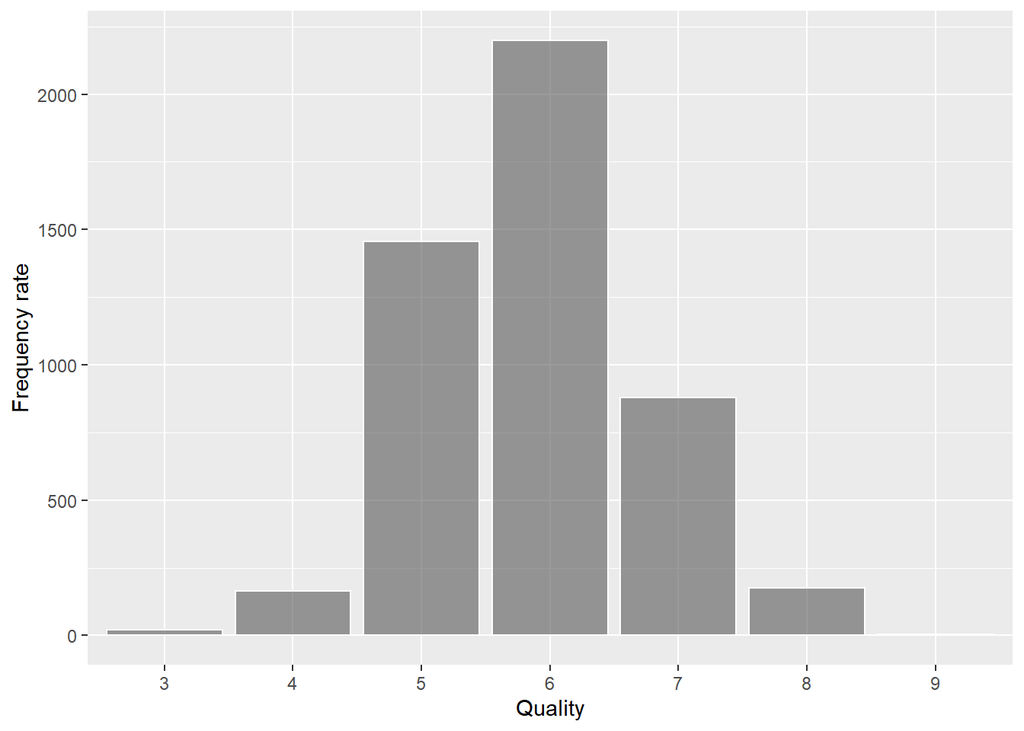

```r
# May be we should start using bar instead of histogram as this looks so ugly
ggplot(wine, aes(quality)) +
  geom_bar(color='white', alpha=0.6) +
  xlab('Quality') +
  ylab('Frequency rate') +
  labs('Quality distribution')
```

**Correlation between variables** Visualizing highly correlated features

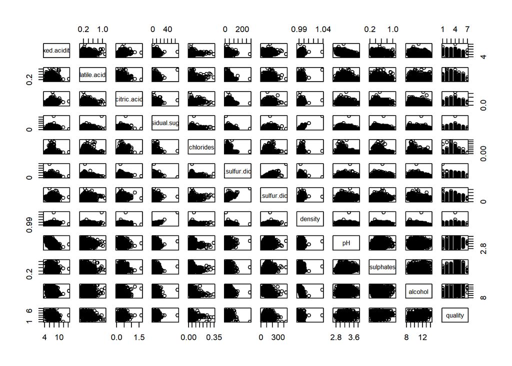

```r
pairs(wine)
```

```r
# # Boolean indices
# wine.low <- wine[, "quality"] < 5
# wine.medium <- wine[, "quality"] >= 5 & wine[, "quality"] <= 7
# wine.high <- wine[, "quality"] > 7
#
# # Categorise quality into three levels for better comparison
# # wine.res = wine restructured
# wine.res <- wine
# wine.res$quality[wine.low] <- 1
# wine.res$quality[wine.medium] <- 2
# wine.res$quality[wine.high] <- 3
```

1. Analysing how various alcohol level affect the overall quality

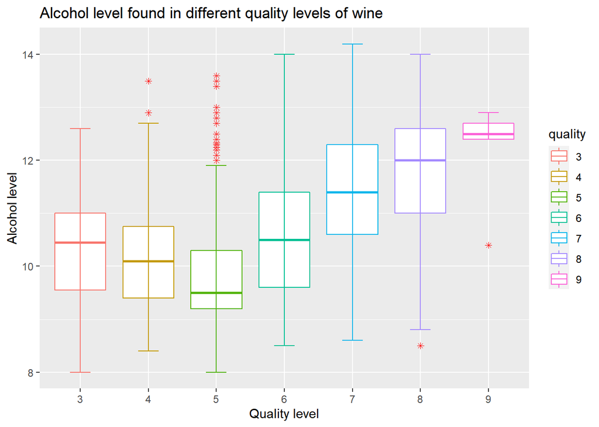

```r
# , fig.width=11, fig.height=4
bp.al <- ggplot(wine, aes(x=quality, y=alcohol, color=quality, group=quality)) +
         geom_boxplot(outlier.shape=8, outlier.color='red') +
         stat_boxplot(geom='errorbar', width=0.3) +
         xlab('Quality level') +
         ylab('Alcohol level') +
         ggtitle('Alcohol level found in different quality levels of wine')

bp.al
```

From the above box and whisker plot, better quality is indeed associated with increased level of alcohol level as was our finding from the prior research. Now, it is time to understand the connection between alcohol level and residual sugar as it was understood from the prior research that high alcohol content is produced by the fermentation process by converting grape sugar into ethanol.

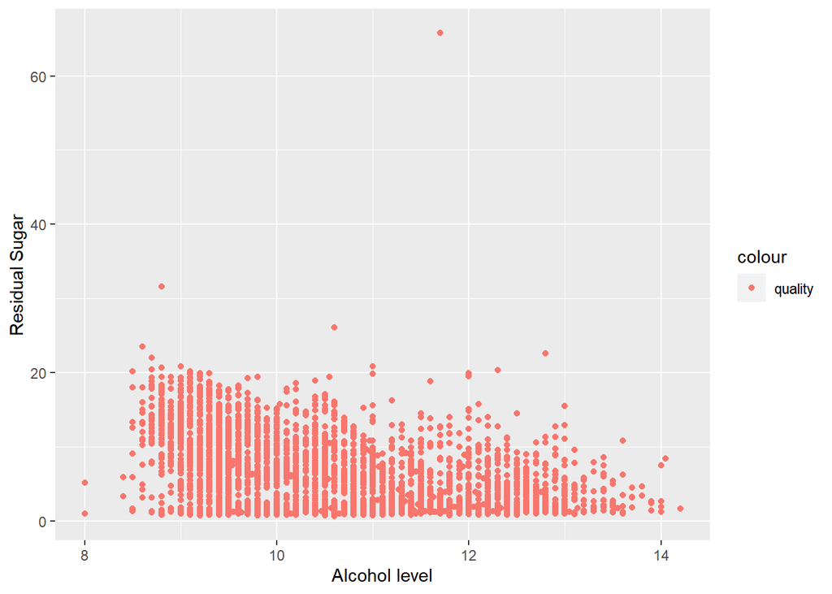

```r
ggplot(wine, aes(x=alcohol, y=residual.sugar, color='quality')) +
geom_point() +
xlab('Alcohol level') +
ylab('Residual Sugar') +
labs('Correlation between alcohol and residual sugar levels')
```

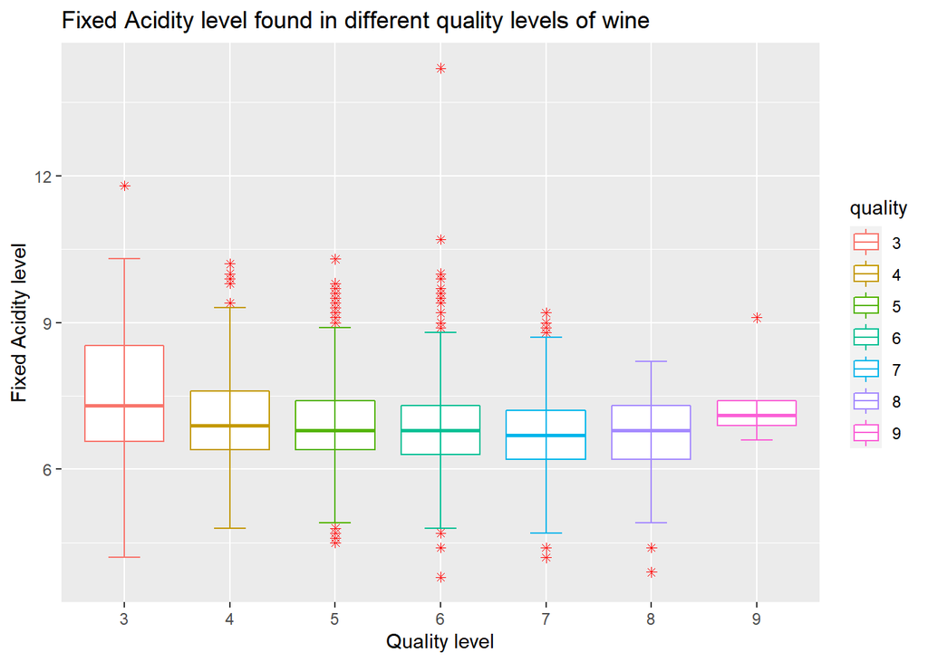

```r
bp.fa <- ggplot(wine, aes(x=quality, y=fixed.acidity, color=quality, group=quality)) +
         geom_boxplot(outlier.shape=8, outlier.color='red') +
         stat_boxplot(geom='errorbar', width=0.3) +
         xlab('Quality level') +
         ylab('Fixed Acidity level') +
         ggtitle('Fixed Acidity level found in different quality levels of wine')

bp.fa
```

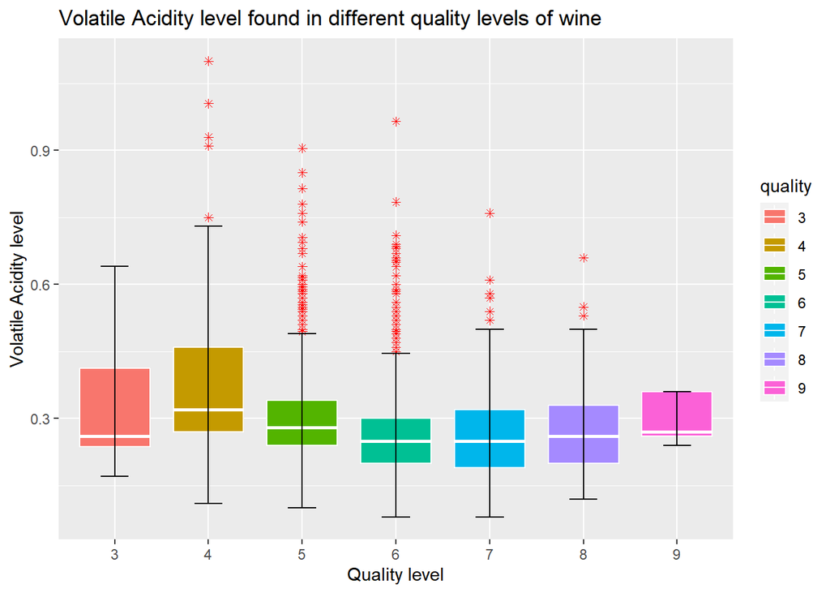

```r
bp.va <- ggplot(wine, aes(x=quality, y=volatile.acidity, fill=quality, group=quality)) +
          geom_boxplot(outlier.shape=8, outlier.color='red', color='white') +
          stat_boxplot(geom='errorbar', width=0.3) +
         xlab('Quality level') +
         ylab('Volatile Acidity level') +
         ggtitle('Volatile Acidity level found in different quality levels of wine')

bp.va
```

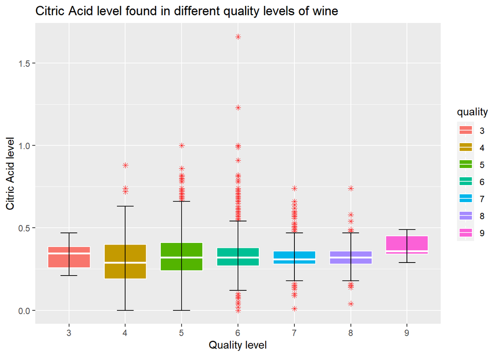

```r
bp.ca <- ggplot(wine, aes(x=quality, y=citric.acid, fill=quality, group=quality)) +
          geom_boxplot(outlier.shape=8, outlier.color='red', color='white') +
          stat_boxplot(geom='errorbar', width=0.3) +
         xlab('Quality level') +
         ylab('Citric Acid level') +
         ggtitle('Citric Acid level found in different quality levels of wine')

bp.ca
```

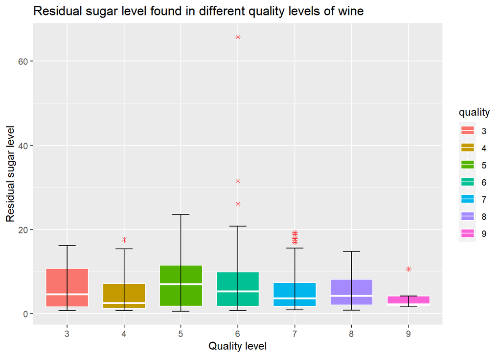

```r
bp.rs <- ggplot(wine, aes(x=quality, y=residual.sugar, fill=quality, group=quality)) +
          geom_boxplot(outlier.shape=8, outlier.color='red', color='white') +
          stat_boxplot(geom='errorbar', width=0.3) +
         xlab('Quality level') +
         ylab('Residual sugar level') +
         ggtitle('Residual sugar level found in different quality levels of wine')

bp.rs
```

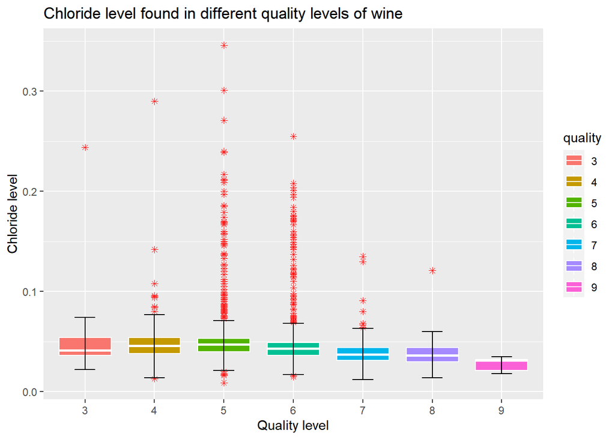

```r
bp.ch <- ggplot(wine, aes(x=quality, y=chlorides, fill=quality, group=quality)) +
          geom_boxplot(outlier.shape=8, outlier.color='red', color='white') +
          stat_boxplot(geom='errorbar', width=0.3) +
         xlab('Quality level') +
         ylab('Chloride level') +
         ggtitle('Chloride level found in different quality levels of wine')

bp.ch
```

[figure not shown]

```r
bp.fsd <- ggplot(wine, aes(x=quality, y=free.sulfur.dioxide, fill=quality, group=quality)) +
          geom_boxplot(outlier.shape=8, outlier.color='red', color='white') +
          stat_boxplot(geom='errorbar', width=0.3) +
          xlab('Quality level') +
          ylab('Chloride level') +
          ggtitle('Free Sulfur Dioxide level found in different quality levels of wine')

bp.fsd
```